# Chi Square Tests Tutorial

Simon Hans Edasi

2023-05-25

### Section 5.2 Chi-square Tests

One population categorized in multiple ways (contingency table analysis). Test of probabilistic independence.

Create the script.

```r
# Clear the memory.

rm(list = ls())



# Load libraries ggplot2, dplyr, and readr
library(ggplot2)
library(dplyr)
library(readr)




# Load the data set "ladybirds_morph_colour"
lady <- read.csv("ladybirds_morph_colour.csv")
```

A biological note from Wikipedia about black and red ladybirds (Adalia bipunctata):

Adalia bipunctata, commonly known as the two-spot ladybird, two-spotted ladybug or two-spotted lady beetle, is a carnivorous beetle of the family Coccinellidae that is found throughout the holarctic region. It is very common in western and central Europe.

To what does holarctic refer? Please look it up.

Distributed in a geographicrange around the North Pole; restricted to arctic regions. I’d like to know the relevance and reason for this distraction.

Check the data set using “View()”.  
NOTE: The “V” is capitalized. This is the raw data. We will go on to summarize the data.

```r
View(lady)


# Look at a horizontal view of the data
# using "glimpse()".
glimpse(lady)
```

```
## Rows: 20
## Columns: 4
## $ Habitat      <chr> "Rural", "Rural", "Rural", "Rural", "Rural", "Rural", "Ru…
## $ Site         <chr> "R1", "R2", "R3", "R4", "R5", "R1", "R2", "R3", "R4", "R5…
## $ morph_colour <chr> "black", "black", "black", "black", "black", "red", "red"…
## $ number       <int> 10, 3, 4, 7, 6, 15, 18, 9, 12, 16, 32, 25, 25, 17, 16, 17…
```

Note: As reminder from the R Tutorials, BC&P pp. 69 - 70 72, piping in R is a method that can be used to replace nesting (composition) of functions and commands making script easier to write and read. Recall that you read the “%>%” as: “put the answer of the left-hand command into the function on the right.” You always start the piping with the name of the data frame. In our case that is “lady”.

```r
totals <- lady %>%
  group_by(Habitat, morph_colour) %>%
    summarise(total.number = sum(number))
totals
```

```
## # A tibble: 4 × 3
## # Groups:   Habitat [2]
##   Habitat    morph_colour total.number
##   <chr>      <chr>               <int>
## 1 Industrial black                 115
## 2 Industrial red                    85
## 3 Rural      black                  30
## 4 Rural      red                    70
```

Display the totals for Rural and Black; Rural and Red; Industrial and Black; and Industrial and Red. These totals are structured as a data frame.

```r
totals
```

```
## # A tibble: 4 × 3
## # Groups:   Habitat [2]
##   Habitat    morph_colour total.number
##   <chr>      <chr>               <int>
## 1 Industrial black                 115
## 2 Industrial red                    85
## 3 Rural      black                  30
## 4 Rural      red                    70
```

Graph the summarized data in a bar chart. Some information about this script:

In the case of count data like this, each bar is one point, we’re not summarizing a distribution, and the counts are ratio data(they have a ‘real’ zero). It is a logical way to view these data, particularly as they have (have you noticed?) no ‘variation’ to examine. In this situation, a bar chart starting at zero is actually a good option.

The ggplot() syntax has some new things:

[1] A new part of the aesthetic, fill = morph_colour. This is used when the ‘geometry’ is something like a bar,and can be filled. Note that colour = morph_colour with a bar alters the outline of the bar, not the fill colour.

[2] geom_bar() has some new arguments

```
 [a] stat = 'identity' tells ggplot not to
     try and calculate anything from the data.
     We want ggplot() to use just what we've
     given it to use.
 [b] position = 'dodge' is a request to put
     the two bars in each Habitat group
     (e.g. black and red counts) next to each
     other. If you don't use the position = 'dodge'
     option you'll end up with a stacked barplot.
```

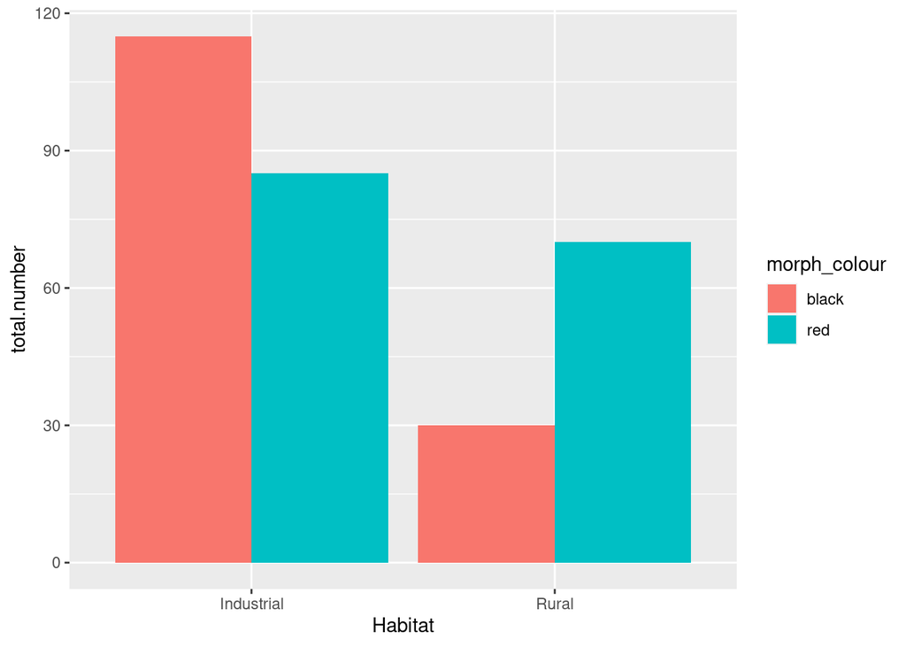

```r
  ggplot(totals, aes(x = Habitat, y = total.number,
    fill = morph_colour)) +
  geom_bar(stat = 'identity', position = 'dodge')
```

Generate a bar chart with the bars colored to represent the colors of the ladybird morphs, i.e., red and black. Do this using the “scale_fill_manual()” function.

Note: when working with discrete groups (as in the variables Habitat and colour_morph), ggplot2 has built-in scale_ functions ending with *manual. See the info about scale*’s in Chapter 8. Here we use scale_fill_manual; it takes an argument called values that is a set of colours to use.

We specify values = c(black= “black”, red = “red”). This seems rather obvious, perhaps, but we are assiging the colours to the appropriate morph_colour. If, for example,the morphs of the ladybirds were large and small, and we wanted to use ‘black’ for large and ‘red’ for small morphs, we would use values = c(large= “black”, small = “red”).

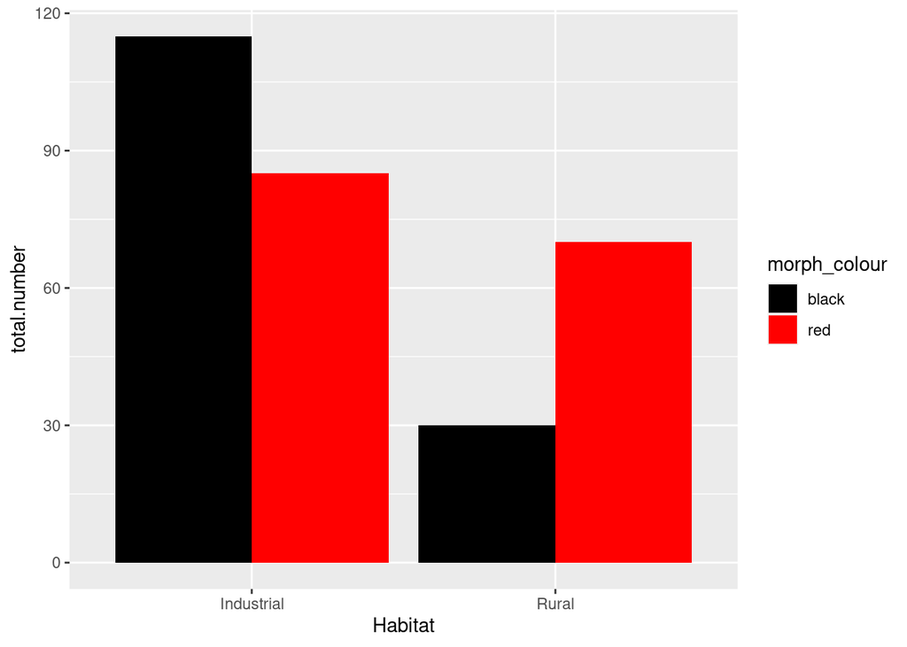

```r
ggplot(totals, aes(x = Habitat, y = total.number,
fill = morph_colour)) +
geom_bar(stat = 'identity', position = 'dodge') +
scale_fill_manual(values = c(black = "black", red = "red"))
```

Review the graph to check validity of our null hypothesis that there is no association between color of the morphs and habitat.

“dplyr” takes and returns a data frame, the chi square test of a contingency table expects to use a matrix of data. We need to modify the structure of our modified data set which we assigned to the object “totals”.

Check the structure of the “totals” data.

```r
str(totals)
```

```
## gropd_df [4 × 3] (S3: grouped_df/tbl_df/tbl/data.frame)
##  $ Habitat     : chr [1:4] "Industrial" "Industrial" "Rural" "Rural"
##  $ morph_colour: chr [1:4] "black" "red" "black" "red"
##  $ total.number: int [1:4] 115 85 30 70
##  - attr(*, "groups")= tibble [2 × 2] (S3: tbl_df/tbl/data.frame)
##   ..$ Habitat: chr [1:2] "Industrial" "Rural"
##   ..$ .rows  : list<int> [1:2]
##   .. ..$ : int [1:2] 1 2
##   .. ..$ : int [1:2] 3 4
##   .. ..@ ptype: int(0)
##   ..- attr(*, ".drop")= logi TRUE
```

Use “xtabs()” to convert the data frame structure into a matrix. This stands for cross(x)-tabulation. This is similar to the pivot table in Microsoft EXCEL.

xtabs() requires a simple formula and a data frame. The data frame in this situation is the raw data from above, lady (although it would also work just fine with the summarized data, totals).

[output not shown]

This “xtabs()” carries out exactly the same calculation as the group_by() and summarise() functions did to make totals, but now we end up with a matrix rather than a data frame.

```r
totals
```

```
## # A tibble: 4 × 3
## # Groups:   Habitat [2]
##   Habitat    morph_colour total.number
##   <chr>      <chr>               <int>
## 1 Industrial black                 115
## 2 Industrial red                    85
## 3 Rural      black                  30
## 4 Rural      red                    70
```

```r
# Display the totals (observed values)
# arranged as matrix data
# in the structure of a 2x2 contingency table.

lady.mat <- xtabs(number ~ Habitat + morph_colour,
                  data = lady)

lady.mat
```

```
##             morph_colour
## Habitat      black red
##   Industrial   115  85
##   Rural         30  70
```

```r
# Display the number of rows
# and columns in "lady.mat".

str(lady.mat)
```

```
##  'xtabs' int [1:2, 1:2] 115 30 85 70
##  - attr(*, "dimnames")=List of 2
##   ..$ Habitat     : chr [1:2] "Industrial" "Rural"
##   ..$ morph_colour: chr [1:2] "black" "red"
##  - attr(*, "call")= language xtabs(formula = number ~ Habitat + morph_colour, data = lady)
```

Let alpha = 0.05.

Let degrees of freedom = df, we know that here df = (number of rows-1)*(number of columns-1).

```r
# Store the alpha and df values
alpha = 0.05
df = (2-1) * (2-1)
# Display the alpha and df.
print(alpha)
```

```
## [1] 0.05
```

```r
print(df)
```

```
## [1] 1
```

Get help on “qchisq()”.

```r
?qchisq()
```

The resulting critical value is found as:

```r
library(glue)
glue('Critical value from a table: {3.841}')
```

```
## Critical value from a table: 3.841
```

```r
# Display the results of the chi square test
chisq.test(lady.mat, correct = TRUE)
```

```
##
##  Pearson's Chi-squared test with Yates' continuity correction
##
## data:  lady.mat
## X-squared = 19.103, df = 1, p-value = 1.239e-05
```

check for what other information is available to us from the chi square test.

```r
lady.chi <- chisq.test(lady.mat)
names(lady.chi)
```

```
## [1] "statistic" "parameter" "p.value"   "method"    "data.name" "observed"
## [7] "expected"  "residuals" "stdres"
```

```
 Display:
```

Note: The “$” is the command (see BC&P p.74) that tells R which column to select from the data set for use. These commands are always available in R.We will make more use of this base R command. Sometimes the old commands make things easier. We will note that again in later assignments.

```r
lady.mat
```

```
##             morph_colour
## Habitat      black red
##   Industrial   115  85
##   Rural         30  70
```

```r
lady.chi$observed
```

```
##             morph_colour
## Habitat      black red
##   Industrial   115  85
##   Rural         30  70
```

```r
lady.chi$expected
```

```
##             morph_colour
## Habitat         black       red
##   Industrial 96.66667 103.33333
##   Rural      48.33333  51.66667
```

```r
lady.chi$statistic
```

```
## X-squared
##  19.10289
```